# Practica 2 - Visualizacion de datos

Carlos Santiago Martinez Torres

2025-05-24

# Configuracion inicial

```r
# Instalacion de librerias con pacman

# Asegurarse de que el paquete 'pacman' está instalado
if (!require("pacman")) install.packages("pacman")

# Poner las librerias necesarias
pacman::p_load(tidyverse, knitr, datasets, RColorBrewer)

# Con tidyverse: ggplot2, dplyr, tidyr, readr, purrr, tibble, stringr, forcats
```

# **Ejercicio 1**

- Carga el fichero `weatherAUS.RData` utilizando lo aprendido en la práctica 1.

```r
# Directorio que contiene los ficheros
carpeta <- 'data/'

f1 <- 'weatherAUS.RData'
f1 <- paste0(carpeta, f1)

load(file = f1)
```

- Crea un objeto ggplot denominado `grafico1` en el que esté definido el conjunto de datos `ds` alojado en el fichero `weatherAUS.RData` y un *aesthetics* en el que en el eje $x$ esté definida la variable `MinTemp` y en el eje $y$ esté definida la variable `MaxTemp`.

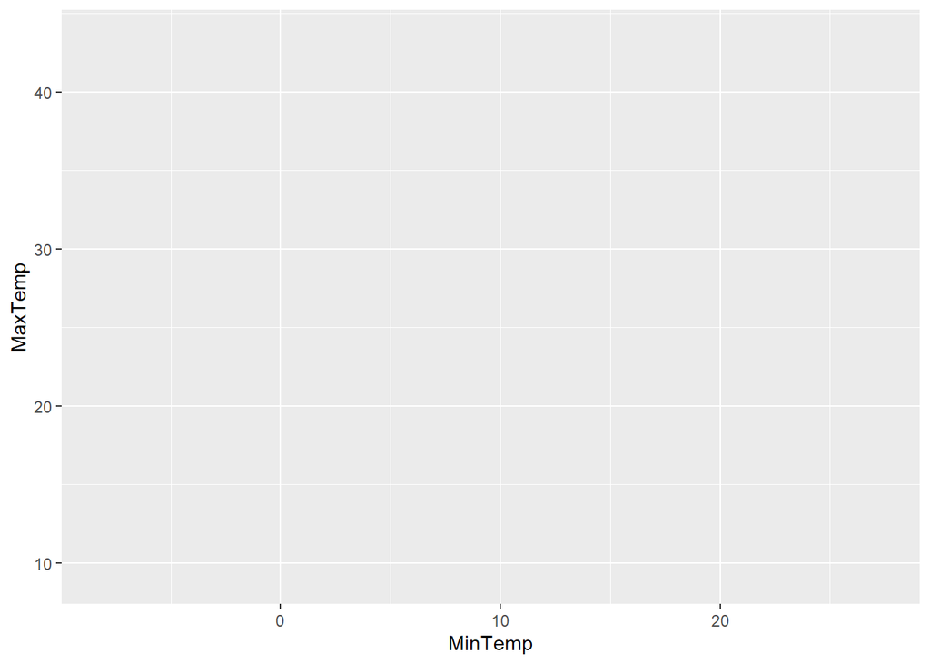

```r
grafico1 <- ggplot(data = ds, mapping = aes(x = MinTemp, y = MaxTemp))
grafico1
```

- Añade una capa que defina el objeto geométrico necesario para construir un gráfico de dispersión de las variables `MinTemp` y `MaxTemp`.

```r
grafico1 <- grafico1 + geom_point()
grafico1
```

[output not shown]

- Genera ahora el mismo gráfico y almacénalo en `grafico2` pero define el *aesthetics* para visualizar las variables `MinTemp` y `MaxTemp` en los ejes de la gráfica y la variable categórica `RainTomorrow` como el color. A partir del objeto `grafico2`, representa un gráfico de dispersión en el que se muestren los puntos con el color del punto correspondiente a la variable `RainTomorrow`.

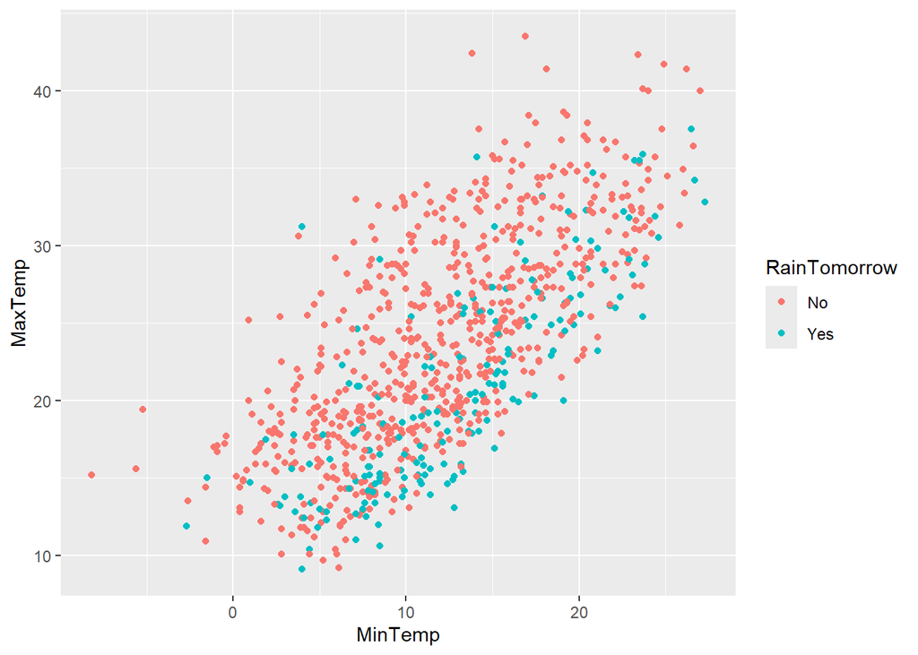

```r
# Las lineas comentadas generan el mismo grafico

# ggplot(data = ds, mapping = aes(x = MinTemp, y = MaxTemp)) + geom_point(mapping = aes(color = RainTomorrow))
ggplot(data = ds, mapping = aes(x = MinTemp, y = MaxTemp, color = RainTomorrow)) + geom_point()
```

```r
# Este elemento es diferente, porque color (aesthetic) no está asignado a una variable
ggplot(data = ds, mapping = aes(x = MinTemp, y = MaxTemp), color = RainTomorrow) + geom_point()
```

[output not shown]

```r
# No tiene a quien asignar el color azul
ggplot(data = ds, mapping = aes(x = MinTemp, y = MaxTemp), color = 'blue') + geom_point()
```

[output not shown]

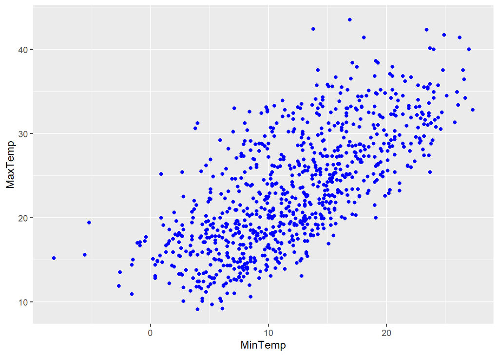

```r
# El color queda 'estatico'
ggplot(data = ds, mapping = aes(x = MinTemp, y = MaxTemp), color = RainTomorrow) + geom_point(color = 'blue')
```

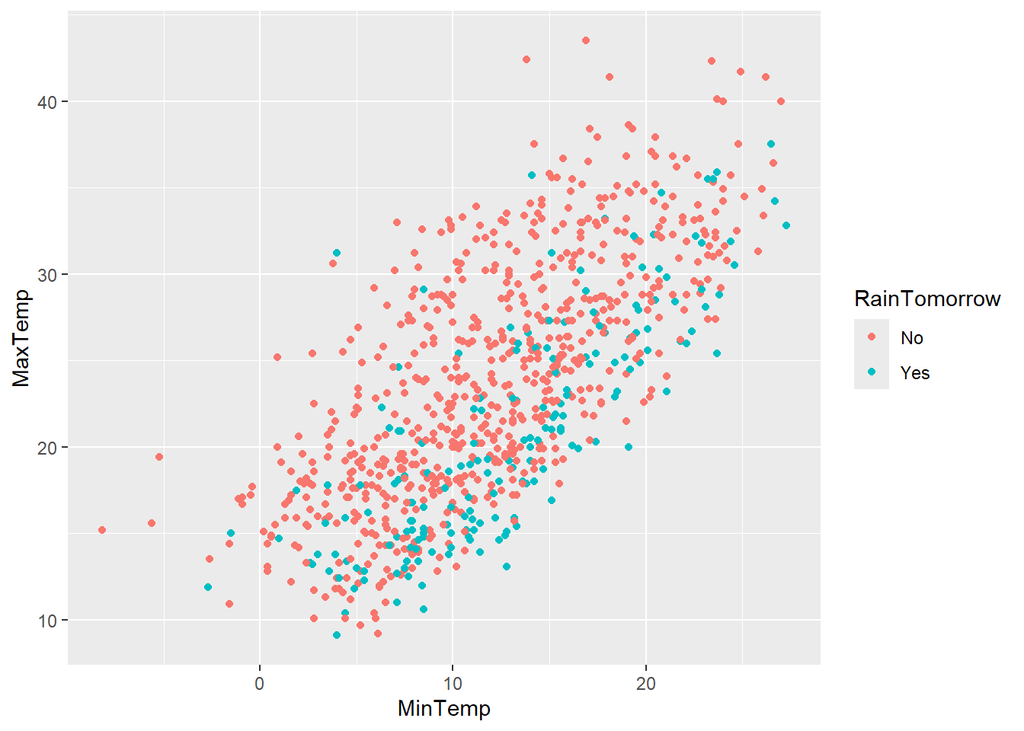

```r
grafico2 <- ggplot(data = ds, mapping = aes(x = MinTemp, y = MaxTemp, color = RainTomorrow)) + geom_point()
grafico2
```

- Añade a `grafico2` una capa para incluir un título con **ggtitle()** y almacénalo en ``grafico3`.

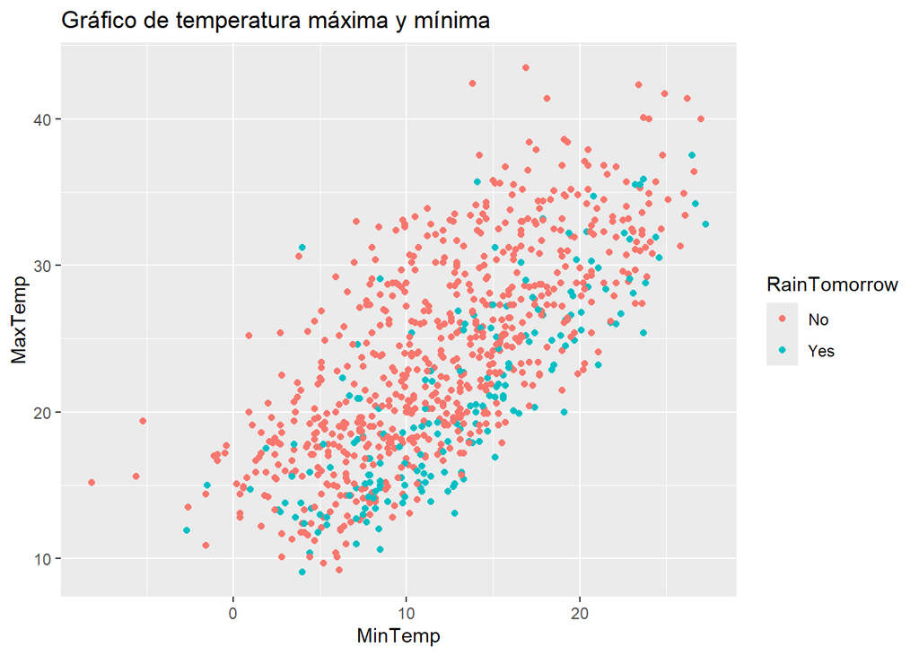

```r
grafico3 <- grafico2 + ggtitle(label = 'Gráfico de temperatura máxima y mínima')
grafico3
```

- Almacena en formato **pdf** el gráfico resultante en un fichero denominado `Ejercicio1.pdf`.

```r
# Directorio que contiene las figuras
figuras <- 'figure/'
n_salida <- '1'
f_salida <- paste0(figuras, 'Ejercicio', n_salida, '.pdf')

# Grafico resultante
pdf(f_salida)
grafico3
dev.off()
```

# **Ejercicio 2**

- Utilizando ggplot haz un grafico de dispersión en el que representes las variables `Temp9am` y `Pressure9am` en los ejes $x$ e $y$ respectivamente.

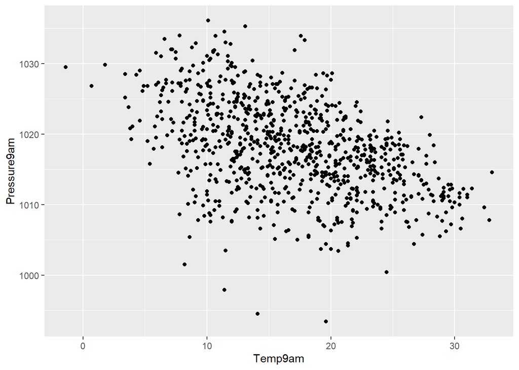

```r
ggplot(data = ds, mapping = aes(x = Temp9am, y = Pressure9am)) + geom_point()
```

- Modifica el gráfico anterior para incluir información categórica proporcionada por la variable `RainToday` con la forma del punto.

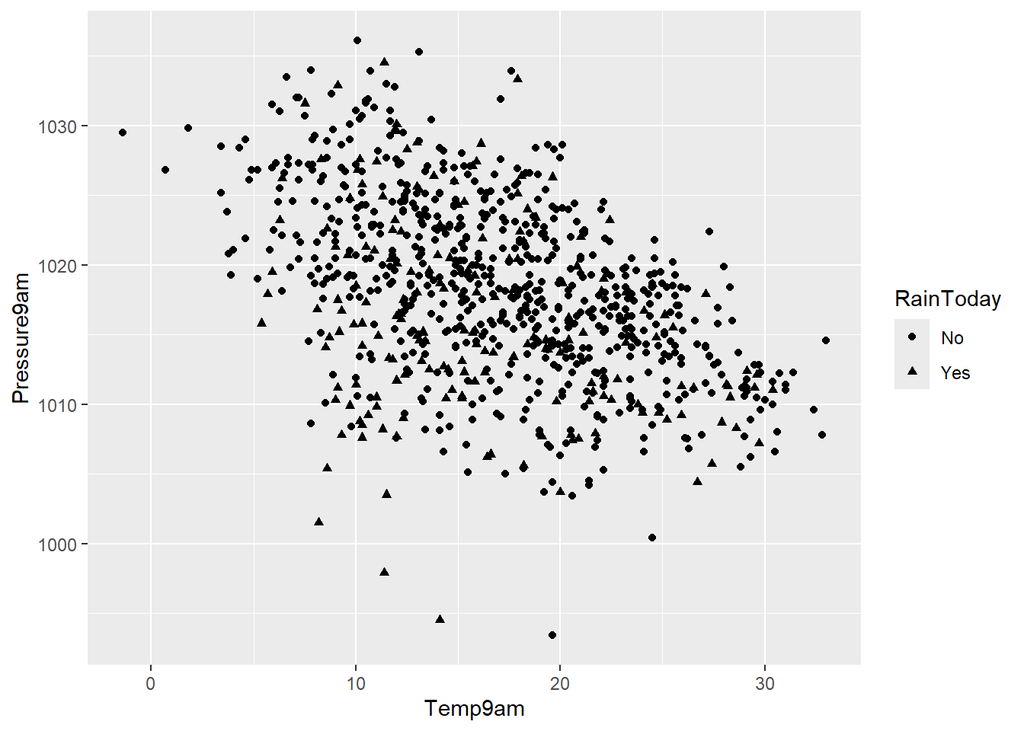

```r
# ggplot(data = ds, mapping = aes(x = Temp9am, y = Pressure9am, shape = RainToday)) + geom_point()
ggplot(data = ds, mapping = aes(x = Temp9am, y = Pressure9am)) + geom_point(aes(shape = RainToday))
```

- Modifica el gráfico anterior para incluir información categórica proporcionada por la variable `RainToday` con el color del punto. ¿Con qué representación (color o forma) se observa mejor la información que introduce la variable `RainToday`?

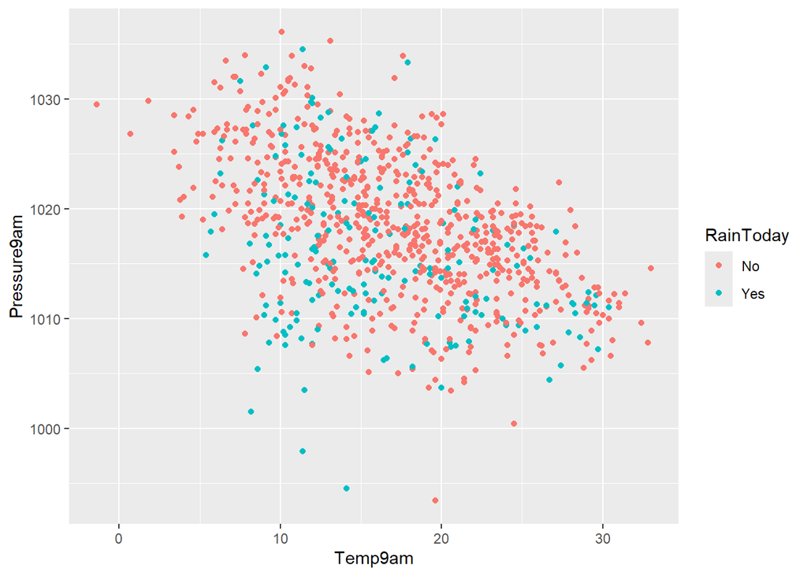

```r
ggplot(data = ds, mapping = aes(x = Temp9am, y = Pressure9am)) + geom_point(aes(color = RainToday))
```

- Añade títulos explicativos al gráfico anterior usando la función (debe aparece un título, subtítulo, leyendas e información de las variables representadas en los ejes).

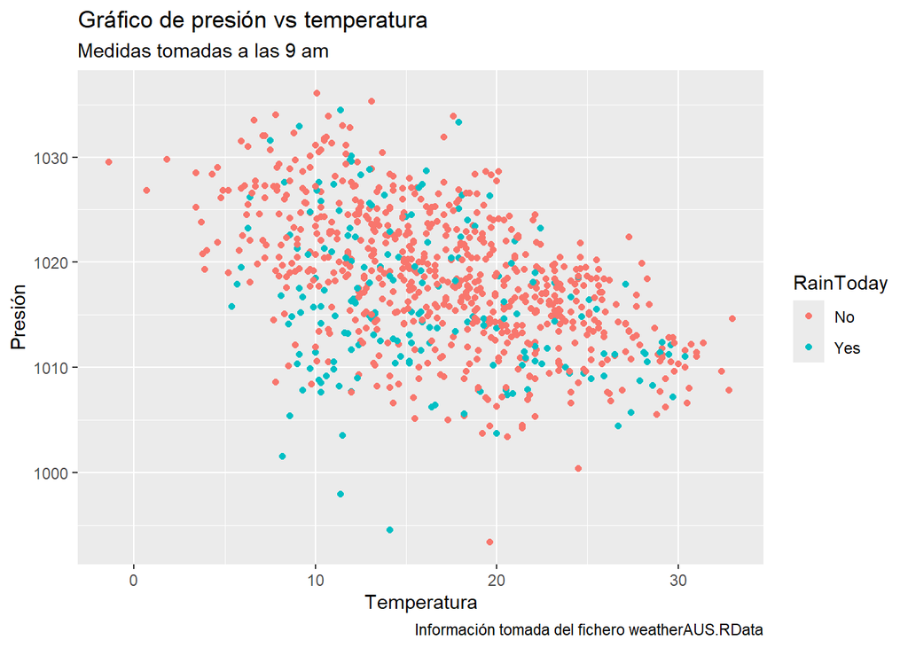

```r
g2 <- ggplot(data = ds, mapping = aes(x = Temp9am, y = Pressure9am)) + geom_point(aes(color = RainToday)) +
  labs(title = 'Gráfico de presión vs temperatura',
       subtitle = 'Medidas tomadas a las 9 am',
       x = 'Temperatura',
       y = 'Presión',
       caption = 'Información tomada del fichero weatherAUS.RData')

g2
```

- Almacena en formato **pdf** el gráfico resultante en un fichero denominado `Ejercicio2.pdf`.

```r
n_salida <- '2'
f_salida <- paste0(figuras, 'Ejercicio', n_salida, '.pdf')

# Grafico resultante
pdf(f_salida)
g2
dev.off()
```

# **Ejercicio 3**

- Carga el fichero `iris.tidy.Rdata` utilizando lo aprendido en la práctica 1.

```r
f2 <- paste0(carpeta, 'iris_tidy.Rdata')
load(f2)
```

- Utiliza la función **str()** para ver qué variables contiene el dataset.

```r
str(iris.tidy)
```

```
## 'data.frame':    600 obs. of  4 variables:
##  $ Species: Factor w/ 3 levels "setosa","versicolor",..: 1 1 1 1 1 1 1 1 1 1 ...
##  $ Part   : Factor w/ 2 levels "Petal","Sepal": 2 2 2 2 2 2 2 2 2 2 ...
##  $ Measure: chr  "Length" "Length" "Length" "Length" ...
##  $ Value  : num  5.1 4.9 4.7 4.6 5 5.4 4.6 5 4.4 4.9 ...
```

- Crea un objeto ggplot denominado `iris.grafico1` en el que esté definido el conjunto de datos `iris.tidy` alojado en el fichero `iris.tidy.RData` y un *aesthetics* en el que en el eje $x$ esté definida la variable `Species` y en el eje $y$ esté definida la variable `Value`.

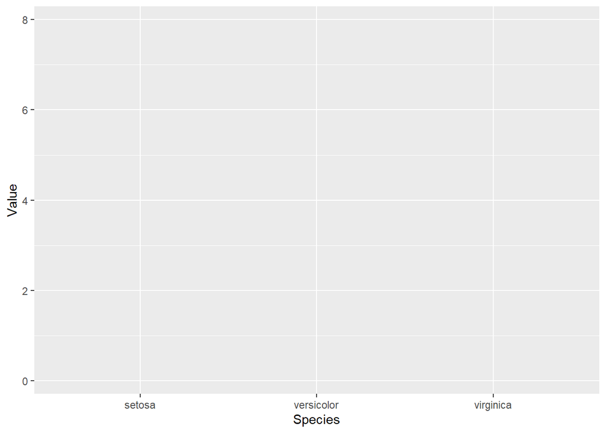

```r
iris.grafico1 <- ggplot(data = iris.tidy, mapping = aes(x = Species, y = Value))
iris.grafico1
```

- Añade una capa que defina el objeto geométrico necesario para construir un gráfico de dispersión de las variables `Species` y `Value`.

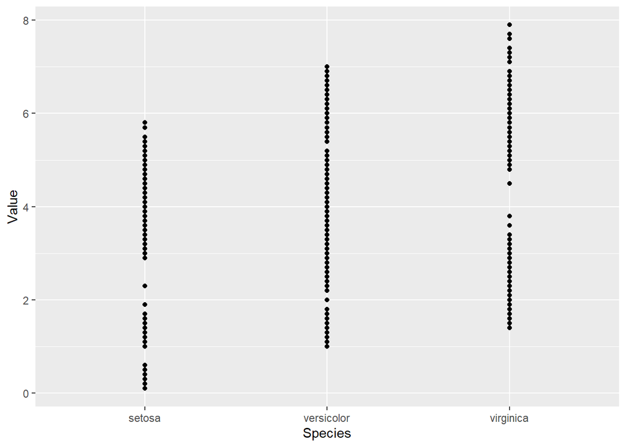

```r
iris.grafico1 + geom_point()
```

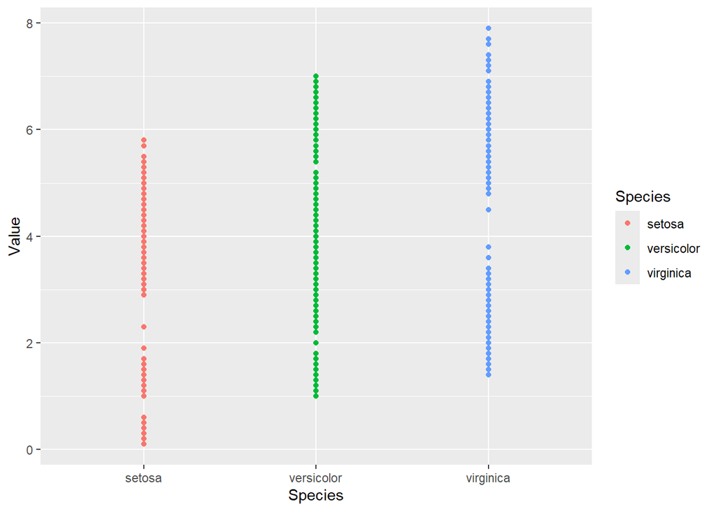

```r
iris.grafico1 + geom_point(aes(color = Species))
```

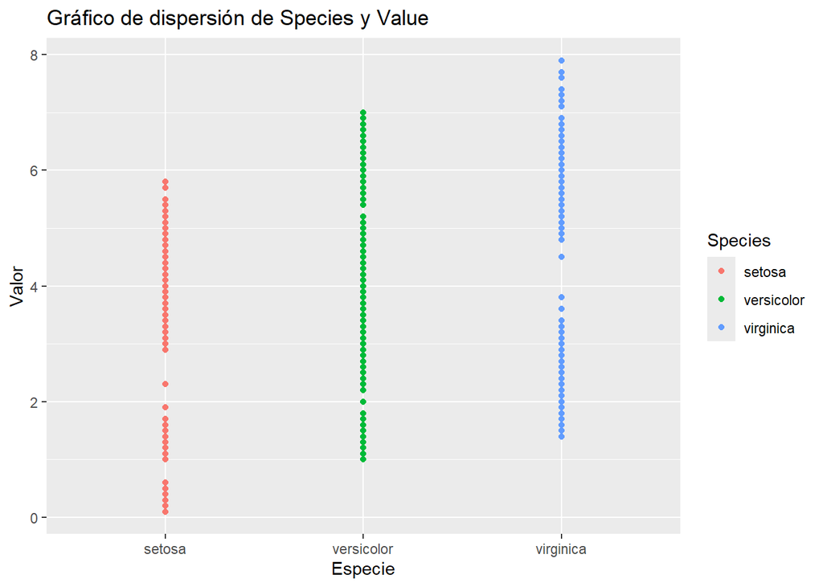

```r
iris.grafico1 + geom_point(aes(color = Species)) + labs(title = 'Gráfico de dispersión de Species y Value',
                                                        x = 'Especie',
                                                        y = 'Valor')
```

- Modifica el *aesthetics* de `iris.grafico1` para visualizar la variable categórica `Part` y almacénalo en `iris.grafico2`. A partir del objeto `iris.grafico2`, representa un gráfico de dispersión en el que se muestren los puntos dados por las variables `Species` y `Value`, y el color del punto se corresponda con el color de la variable `Part`.

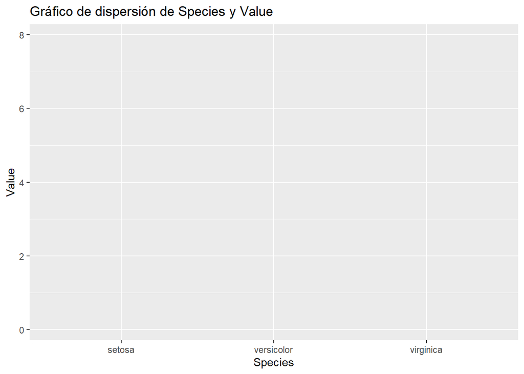

```r
iris.grafico2 <- ggplot(data = iris.tidy,
                        mapping = aes(x = Species, y = Value, color = Part)) +
                  ggtitle('Gráfico de dispersión de Species y Value')
iris.grafico2
```

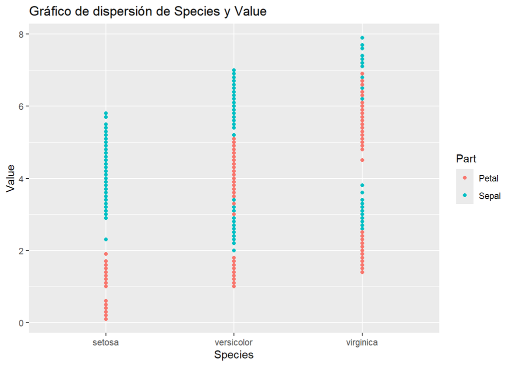

```r
iris.grafico2 + geom_point()
```

- Incluye información de la variable `Measure` haciendo dos gráficos de dispersión (dispuestos en filas) con **facet_grid()** como en el apartado de introducción para los dos valores que toma la variable `Measure`. Prueba a cambiar la disposición de los gráficos para que sea en columnas ¿Qué disposición, en filas o en columnas, permite comparar mejor los valores de las dos variables?

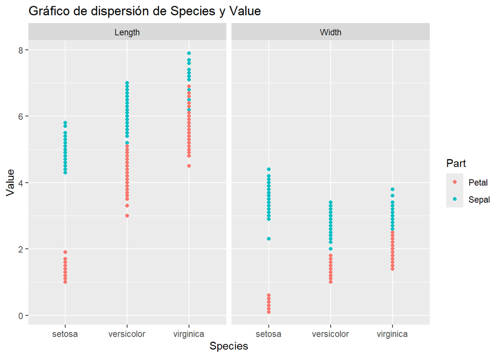

```r
# iris.grafico2 + facet_grid(~ Measure)
iris.grafico2 + geom_point() + facet_grid(.~Measure) # Forma vertical
```

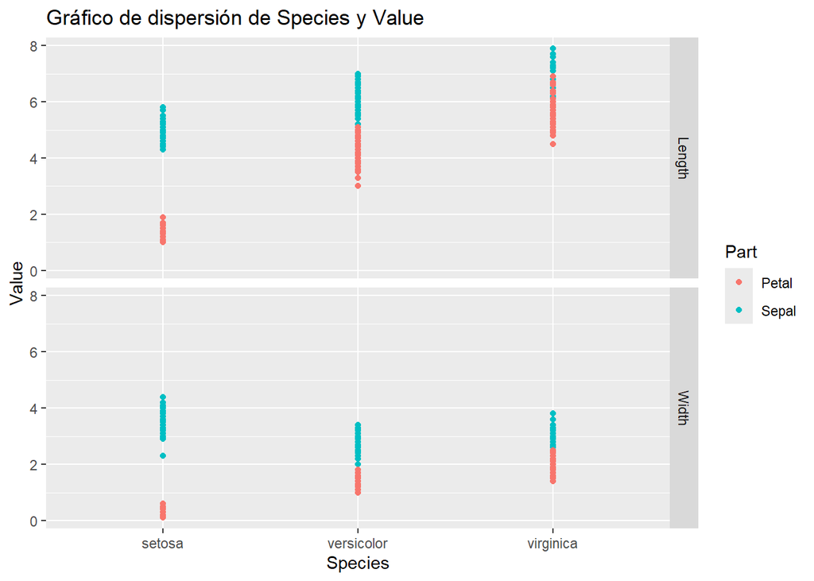

```r
iris.grafico2 + geom_point() + facet_grid(Measure~.) # Forma horizontal
```

- Cambia ahora la capa **geom_point()** del gráfico anterior por la capa **geom_jitter()**. ¿Qué diferencia observas?

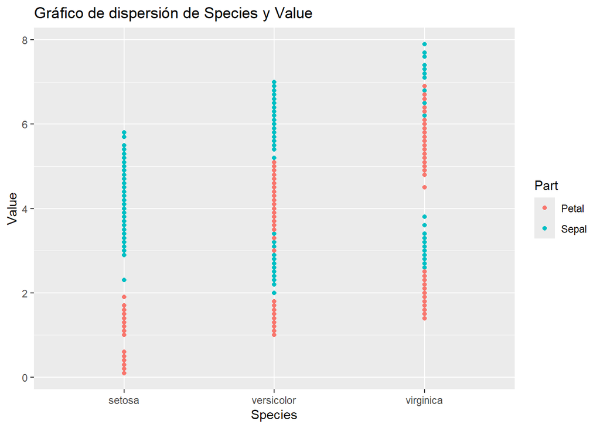

```r
iris.grafico2 + geom_point()
```

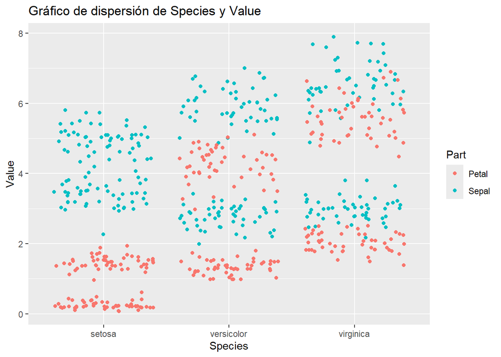

```r
g3 <- iris.grafico2 + geom_jitter()
g3
```

- Almacena en formato **pdf** el gráfico resultante en un fichero denominado `Ejercicio3.pdf`.

```r
n_salida <- '3'
f_salida <- paste0(figuras, 'Ejercicio', n_salida, '.pdf')

# Grafico resultante
pdf(f_salida)
g3
dev.off()
```

# **Ejercicio 4**

- Carga el fichero `Ejercicio4_Data.Rdata`. Examina las variables que tiene dicho dataset.

```r
f3 <- paste0(carpeta, 'Ejercicio4_Data.Rdata')
load (f3)
```

- Representa un gráfico de puntos, en el que se muestre la fecha en el eje $x$ y las ventas en el eje $y$. Queremos que los datos de cada fabricante sean de un color distinto. ¿Es este gráfico valido para evaluar la evolución de las ventas de cada fabricante?

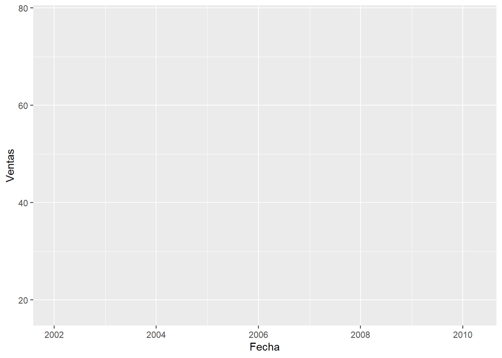

```r
g4 <- ggplot(data = DatosEjer4, mapping = aes(x = Fecha, y = Ventas))
g4
```

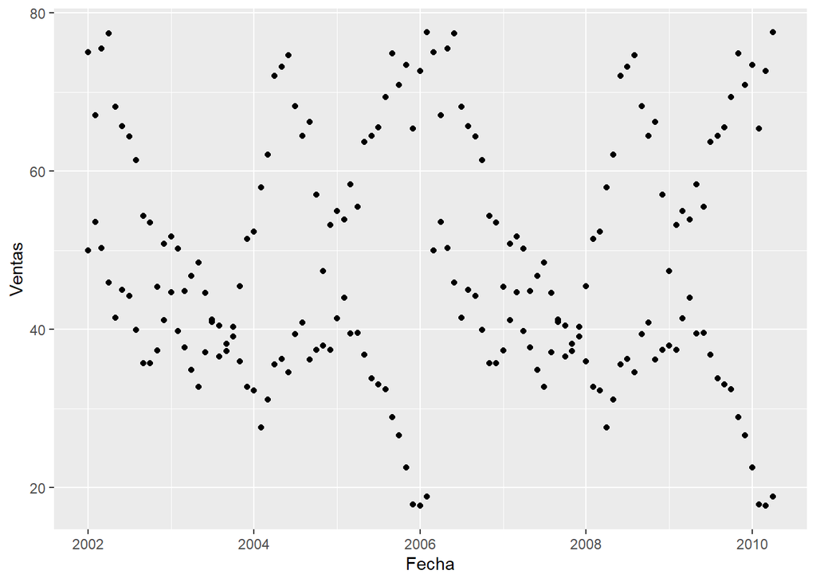

```r
g4  + geom_point()
```

- Representa un gráfico como el anterior en el que se muestre la línea que une los puntos que antes has representado.

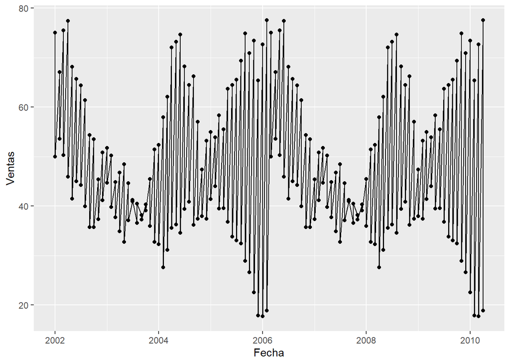

```r
g4 + geom_point() + geom_line()
```

- Modifica el gráfico anterior para que la tendencia de cada fabricante este trazada con un tipo de línea diferente.

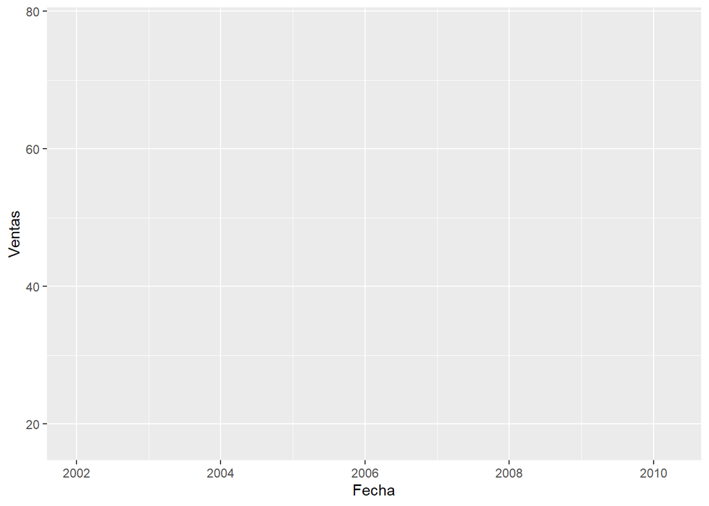

```r
g4 <- ggplot(data = DatosEjer4, mapping = aes(x = Fecha, y = Ventas, group = Fabricante))
g4 # Ahora está agrupado por Fabricante
```

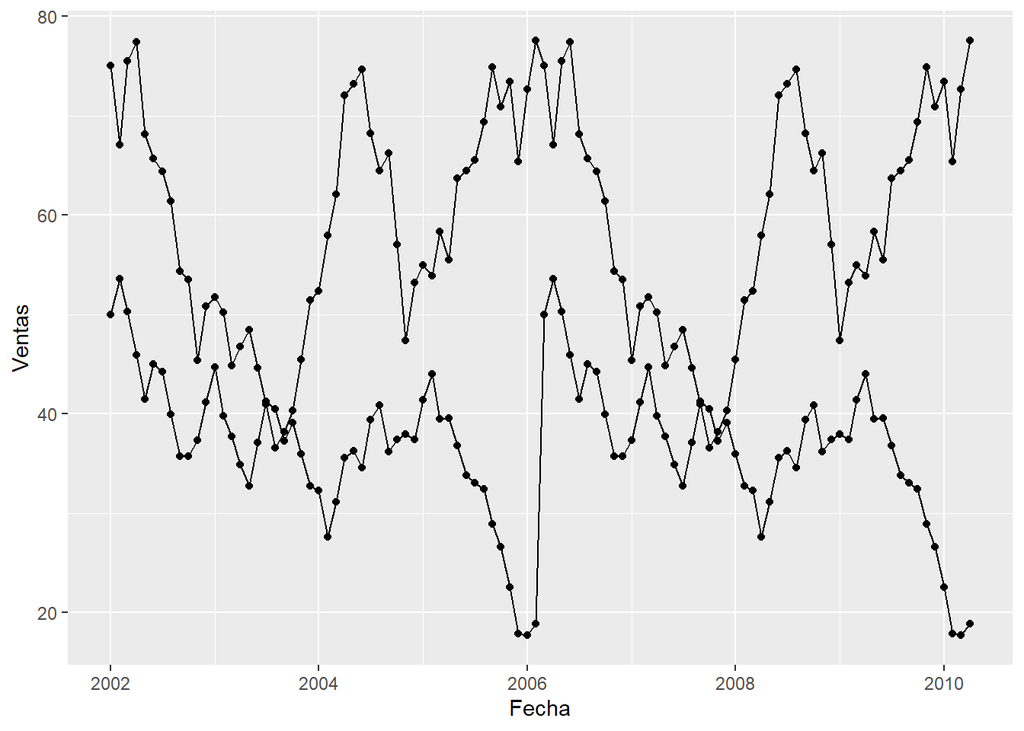

```r
g4 + geom_point() + geom_line()
```

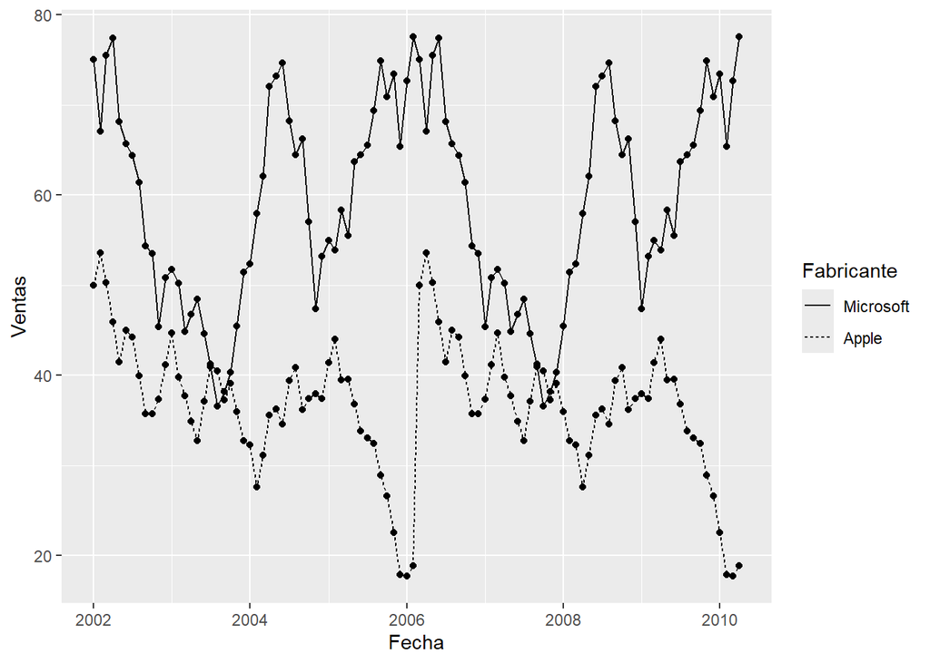

```r
g4 + geom_point() + geom_line(aes(linetype = Fabricante))
```

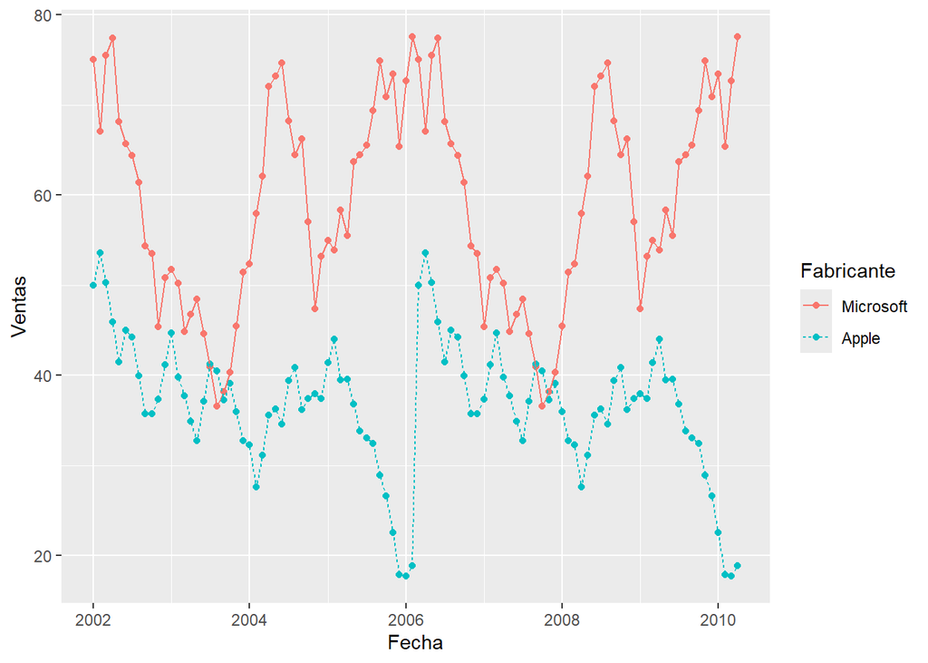

```r
g4 + geom_point(aes(color = Fabricante)) + geom_line(aes(linetype = Fabricante, color = Fabricante))
```

- Añade el siguiente título al gráfico *“Ventas mensuales de diferentes compañías tecnológicas”*.

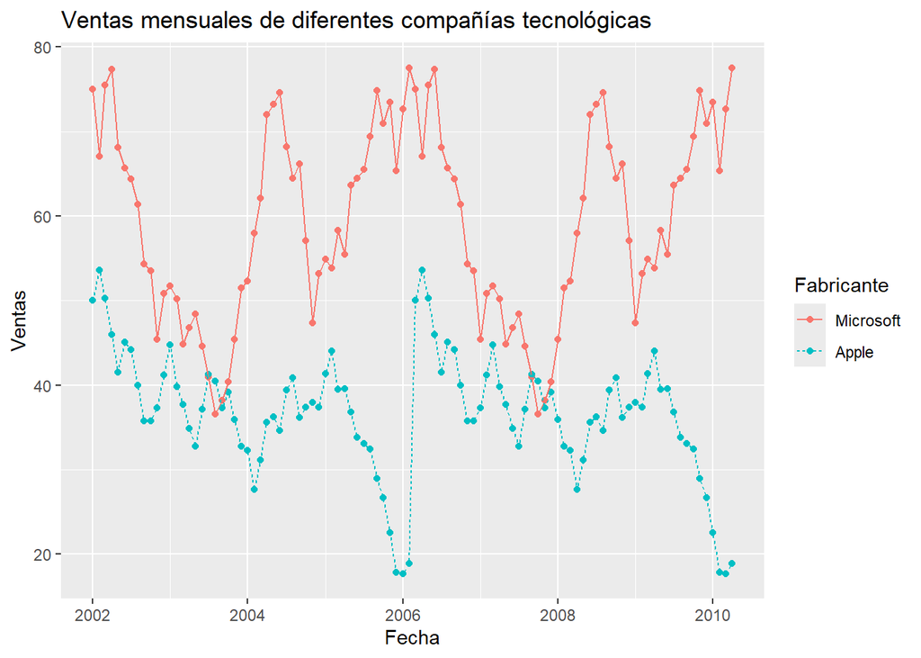

```r
g4 <- g4 + geom_point(aes(color = Fabricante)) + geom_line(aes(linetype = Fabricante, color = Fabricante)) +
  ggtitle(label = 'Ventas mensuales de diferentes compañías tecnológicas')
g4
```

- Almacena en formato **pdf** el gráfico resultante en un fichero denominado `Ejercicio4.pdf`.

```r
n_salida <- '4'
f_salida <- paste0(figuras, 'Ejercicio', n_salida, '.pdf')

# Grafico resultante
pdf(f_salida)
g4
dev.off()
```

# **Ejercicio 5**

Añadir barras de error a un gráfico de línea.

- Carga el fichero `Experimento.Rdata`. Examina las variables que tiene dicho dataset.

```r
f4 <- paste0(carpeta, 'Experimento.Rdata')
load(f4)
```

- Representa un gráfico de puntos, en la que se muestre la `Dosis` en el eje $x$ y la `Altura` en el eje $y$. Queremos que los datos de cada `Complemento` se represente en una línea diferente con diferentes trazos. Hazlo incluyendo las opciones de tipo de línea y forma del punto dentro del **aes()** de la capa **ggplot**.

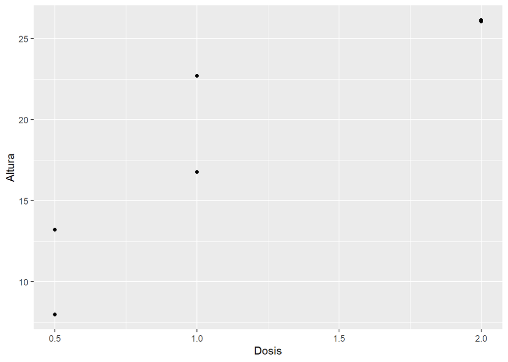

```r
ggplot(data = Experimento, mapping = aes(x = Dosis, y = Altura, group = Complemento)) + geom_point()
```

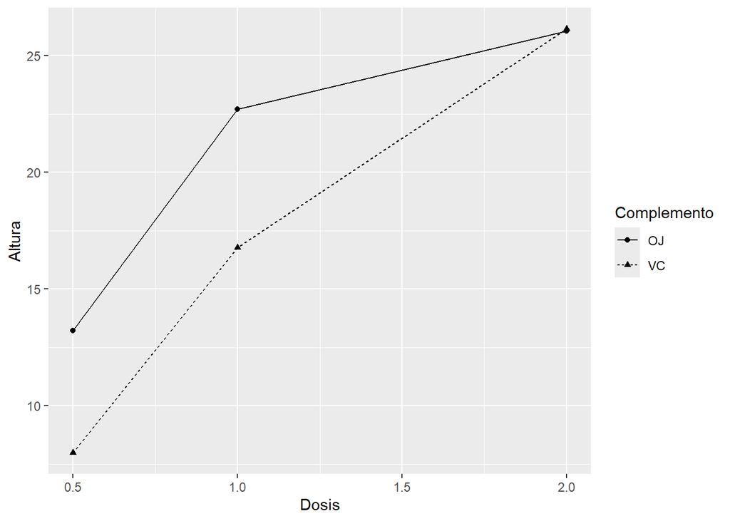

```r
ggplot(data = Experimento, mapping = aes(x = Dosis, y = Altura, group = Complemento)) +
  geom_point(aes(shape = Complemento)) + geom_line(aes(linetype = Complemento))
```

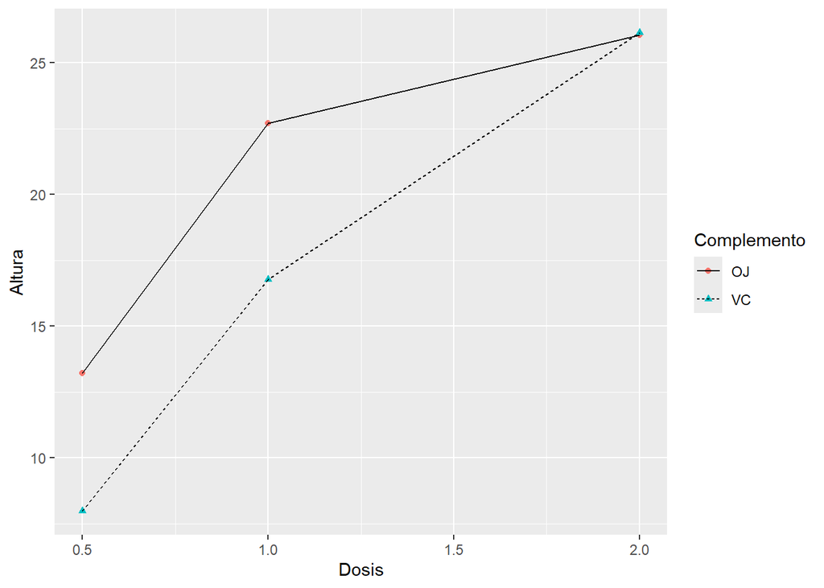

```r
# Color se puede pasar a cada geom_function, o bien, en el 'general' de ggplot
ggplot(data = Experimento, mapping = aes(x = Dosis, y = Altura, group = Complemento)) +
  geom_point(aes(shape = Complemento, color = Complemento)) + geom_line(aes(linetype = Complemento))
```

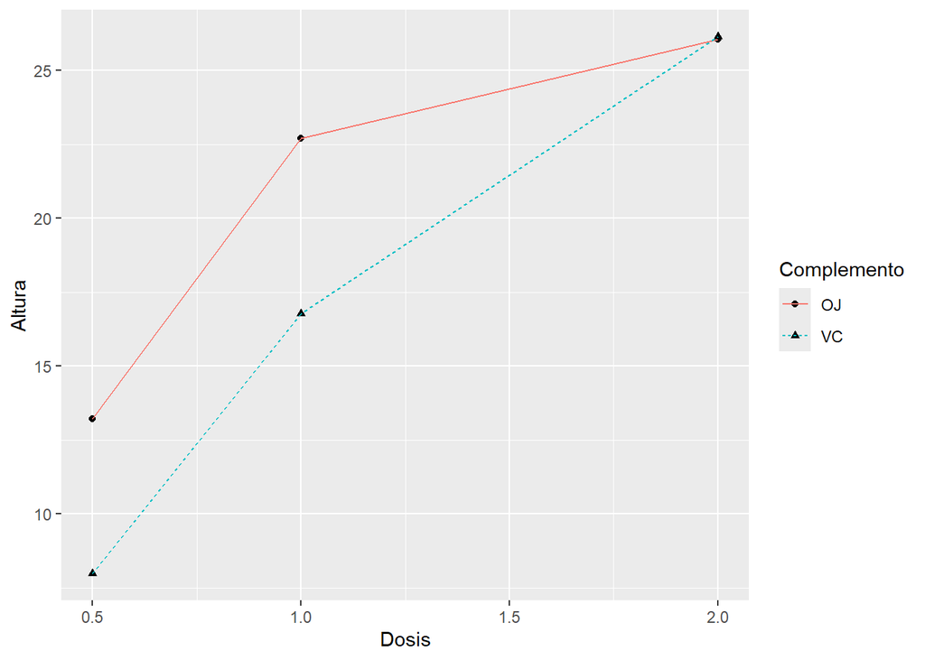

```r
ggplot(data = Experimento, mapping = aes(x = Dosis, y = Altura, group = Complemento)) +
  geom_point(aes(shape = Complemento)) + geom_line(aes(linetype = Complemento, color = Complemento))
```

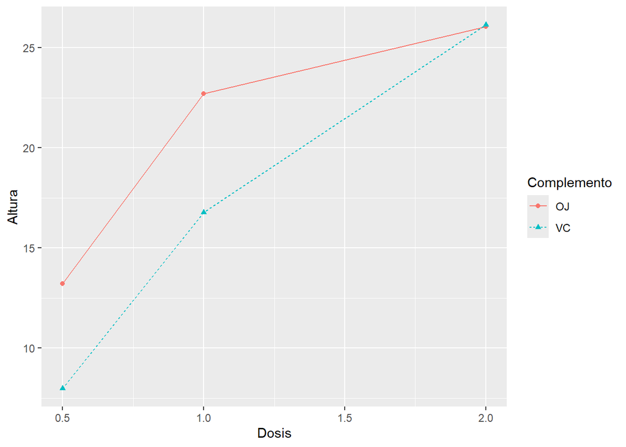

```r
# Estos son los finales, y representan lo mismo
ggplot(data = Experimento,
       mapping = aes(x = Dosis, y = Altura, group = Complemento, color = Complemento, shape = Complemento, linetype = Complemento)) +
  geom_point() + geom_line()
```

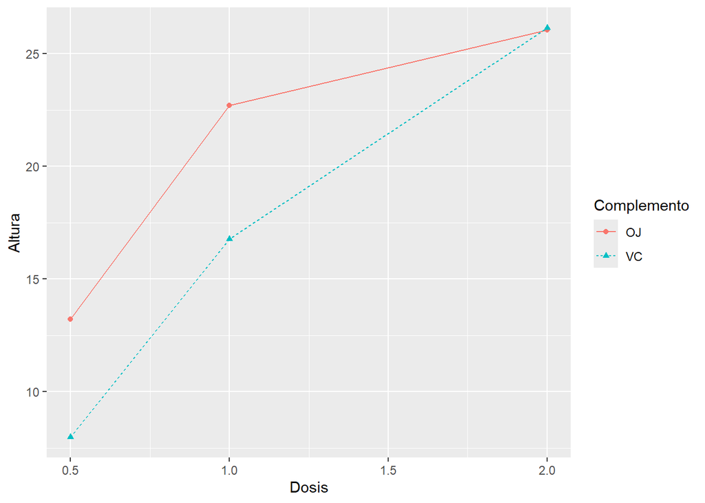

```r
ggplot(data = Experimento, mapping = aes(x = Dosis, y = Altura, group = Complemento, color = Complemento)) +
  geom_point(aes(shape = Complemento)) + geom_line(aes(linetype = Complemento))
```

- Crea otro gráfico a partir de añadir al gráfico anterior barras de error a cada punto. El error viene dado por la variable `Error_Altura`.

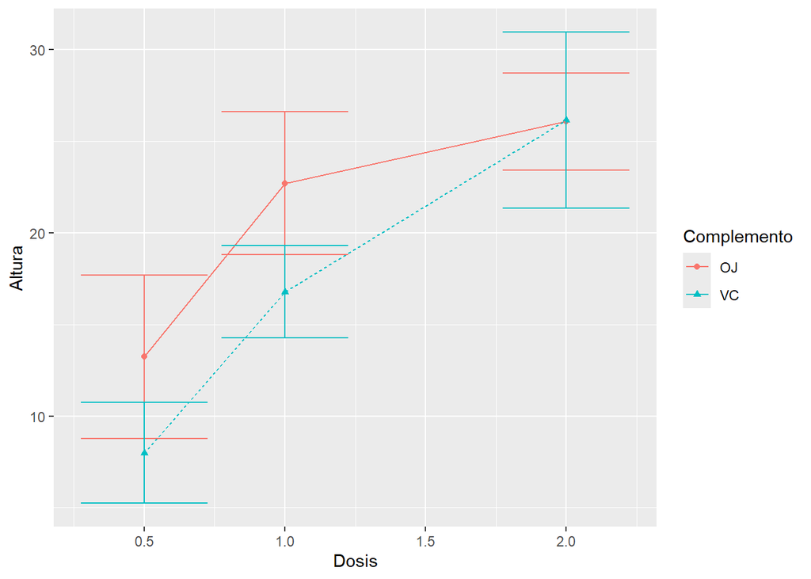

```r
ggplot(data = Experimento, mapping = aes(x = Dosis, y = Altura, group = Complemento, color = Complemento)) +
  geom_point(aes(shape = Complemento)) + geom_line(aes(linetype = Complemento)) +
  geom_errorbar(aes(ymin = Altura - Error_Altura, ymax = Altura + Error_Altura))
```

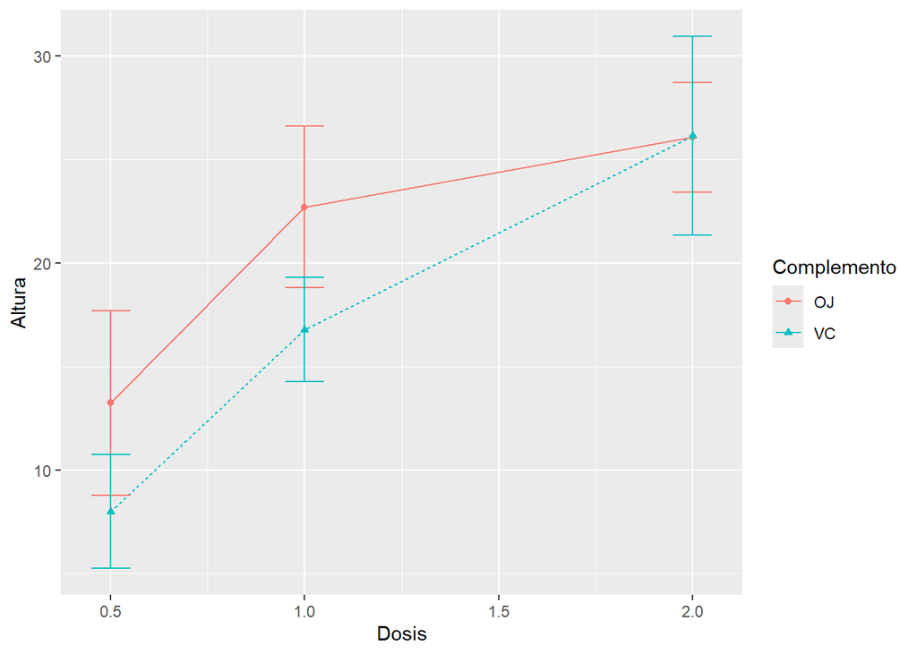

```r
ggplot(data = Experimento, mapping = aes(x = Dosis, y = Altura, group = Complemento, color = Complemento)) +
  geom_point(aes(shape = Complemento)) + geom_line(aes(linetype = Complemento)) +
  geom_errorbar(aes(ymin = Altura - Error_Altura, ymax = Altura + Error_Altura), width = 0.1)
```

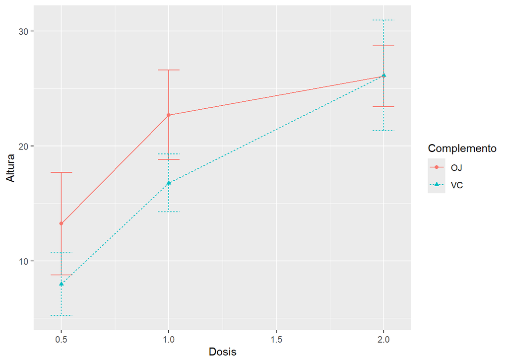

```r
# En este caso, cambia la linea de las barras de error, ya que es el general 'ggplot', que tiene la configuracion
ggplot(data = Experimento,
       mapping = aes(x = Dosis, y = Altura, group = Complemento, color = Complemento, shape = Complemento, linetype = Complemento)) +
  geom_point() +
  geom_line() +
  geom_errorbar(aes(ymin = Altura - Error_Altura, ymax = Altura + Error_Altura), width = 0.1)
```

- Crea otro gráfico, como el anterior (**idéntico**), pero en este caso no puedes incluir el tipo de línea y el tipo de punto en el aes() de la capa ggplot. Además queremos que la paleta de colores sea en tonos de azules.

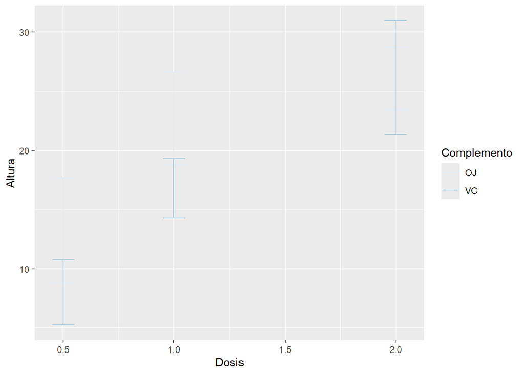

```r
ggplot(data = Experimento,
       mapping = aes(x = Dosis, y = Altura, group = Complemento, color = Complemento)) +
  geom_errorbar(aes(ymin = Altura - Error_Altura, ymax = Altura + Error_Altura), width = 0.1) +
  # theme_classic() +
  scale_color_brewer(palette = 'Blues') # Colores muy claros
```

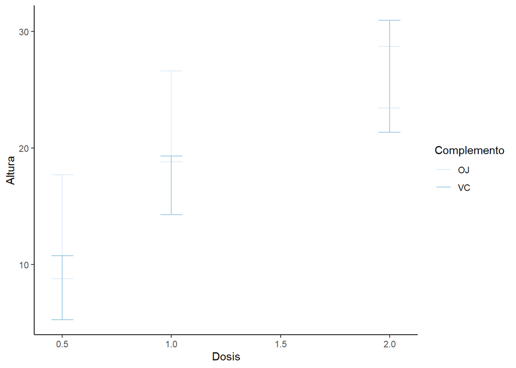

```r
# Haciendo uso de theme, se evidencia mejor
ggplot(data = Experimento,
       mapping = aes(x = Dosis, y = Altura, group = Complemento, color = Complemento)) +
  geom_errorbar(aes(ymin = Altura - Error_Altura, ymax = Altura + Error_Altura), width = 0.1) +
  theme_classic() +
  scale_color_brewer(palette = 'Blues')
```

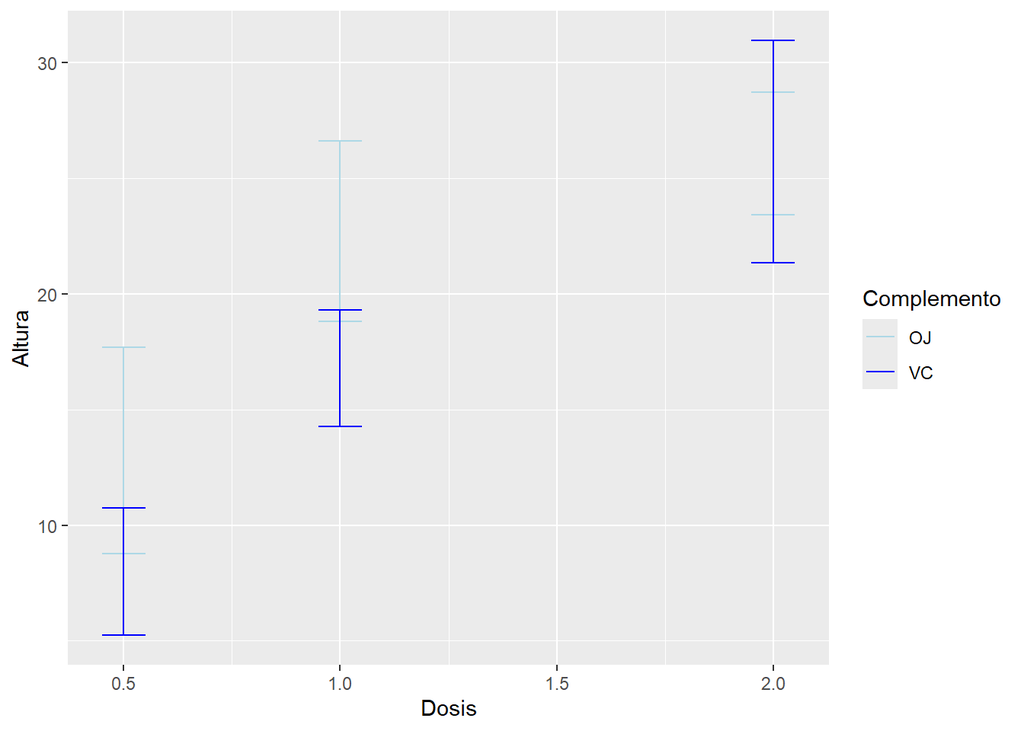

```r
# También se puede
g5 <- ggplot(data = Experimento,
       mapping = aes(x = Dosis, y = Altura, group = Complemento, color = Complemento)) +
  geom_errorbar(aes(ymin = Altura - Error_Altura, ymax = Altura + Error_Altura), width = 0.1) +
  # theme_classic() +
  # scale_color_brewer(palette = 'Blues')
  scale_color_manual(values = c("lightblue", "blue"))
g5
```

```r
# ggplot(data = Experimento,
#        mapping = aes(x = Dosis, y = Altura, group = Complemento, color = Complemento)) +
#   geom_errorbar(aes(ymin = Altura - Error_Altura, ymax = Altura + Error_Altura), width = 0.1) +
#   # theme_classic() +
#   # scale_color_brewer(palette = 'Blues')
#   # scale_color_manual(values = c("lightblue", "blue"))
#   scale_color_viridis_d() # la letra _d, es para valores discretos
```

- Almacena en formato **pdf** el gráfico resultante en un fichero denominado `Ejercicio5.pdf`.

```r
n_salida <- '5'
f_salida <- paste0(figuras, 'Ejercicio', n_salida, '.pdf')

# Grafico resultante
pdf(f_salida)
g5
dev.off()
```

# **Ejercicio 6**

- Carga el fichero `weatherAUS_distributions.RData`.

```r
f5 <- paste0(carpeta, 'weatherAUS_distributions.RData')
load(f5)
```

- Crea un gráfico en el que estén los boxplots de la variable `MinTemp` para cada uno de los años presentes en la variable `Year` del dataset.

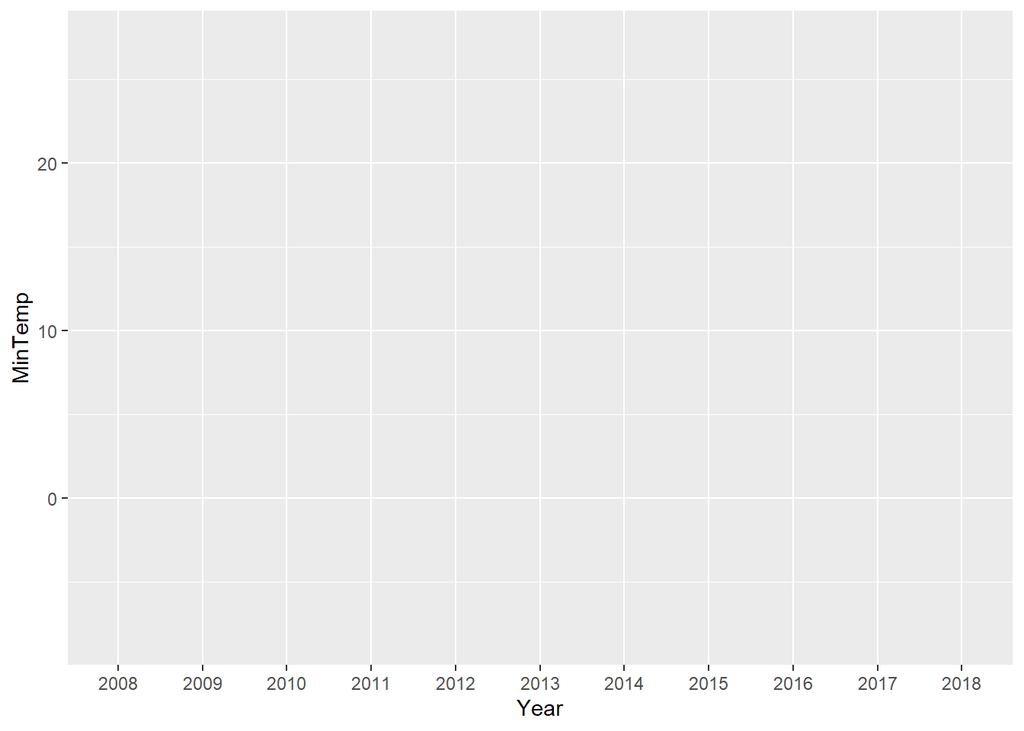

```r
g6 <- ggplot(data = ds, mapping = aes(x = Year, y = MinTemp))
g6
```

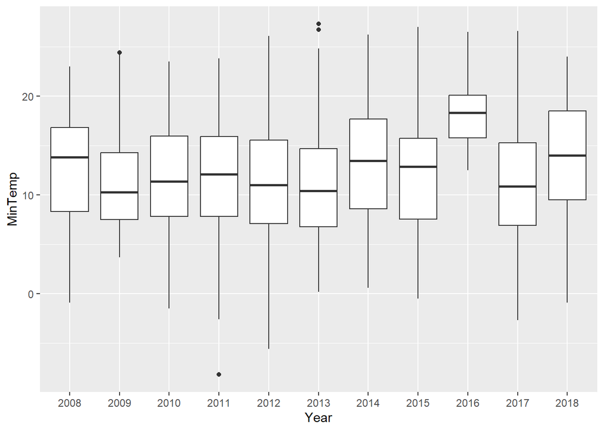

```r
g6 + geom_boxplot()
```

- Crea un gráfico en el que estén los gráficos de violín de la variable `MaxTemp` para cada uno de los años presentes en la variable `Year` del dataset. Añade en el mismo gráfico una capa de etiquetas de título (Distribución de temperaturas máximas por año), eje $x$ (Año) y eje $y$ (Temperatura (ºC)). Colorea el interior de los violines según la la variable `Year`.

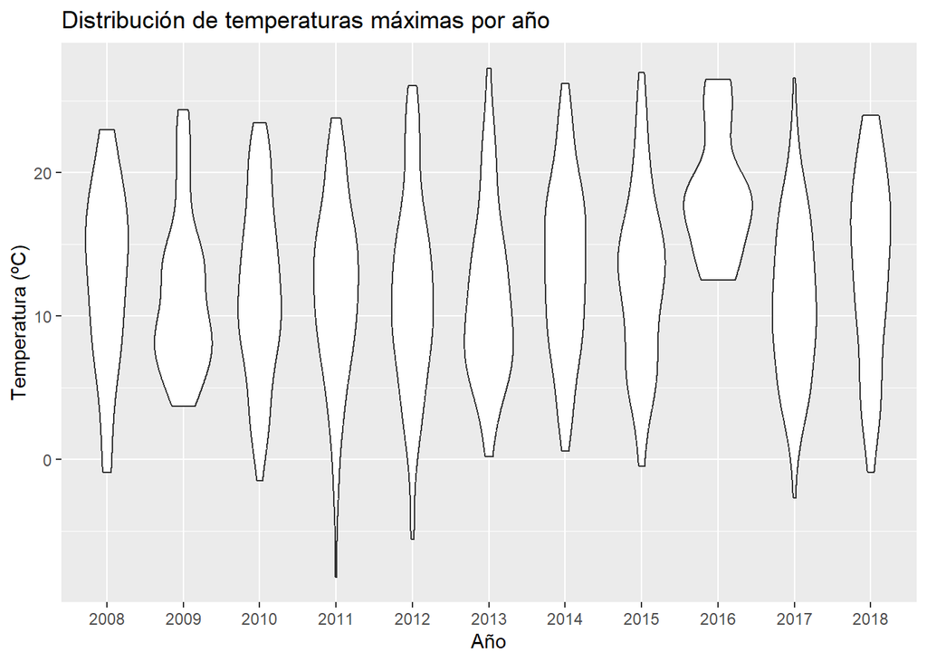

```r
# Si el color no esta en ggplot y geom_violin no tiene fill
ggplot(data = ds, mapping = aes(x = Year, y = MinTemp)) +
  geom_violin() +
  ggtitle(label = 'Distribución de temperaturas máximas por año') +
  xlab(label = 'Año') + ylab(label = 'Temperatura (ºC)')
```

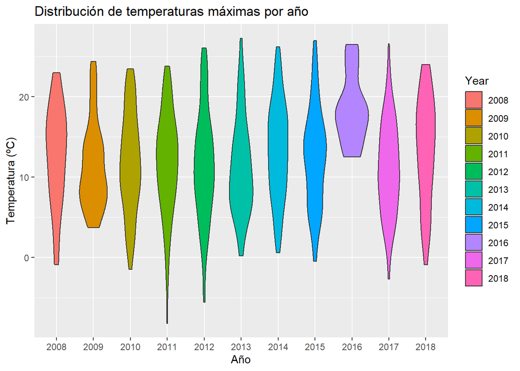

```r
# Si ggplot no tiene el color, pero violin si tiene fill
ggplot(data = ds, mapping = aes(x = Year, y = MinTemp)) +
  geom_violin(aes(fill = Year)) +
  ggtitle(label = 'Distribución de temperaturas máximas por año') +
  xlab(label = 'Año') + ylab(label = 'Temperatura (ºC)')
```

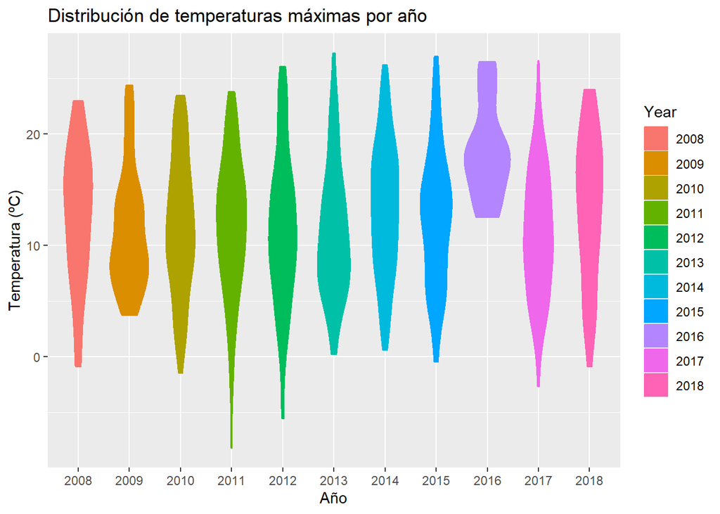

```r
# Colo esta en ggplot y violin
ggplot(data = ds, mapping = aes(x = Year, y = MinTemp, color = Year)) +
  geom_violin(aes(fill = Year)) +
  ggtitle(label = 'Distribución de temperaturas máximas por año') +
  xlab(label = 'Año') + ylab(label = 'Temperatura (ºC)')
```

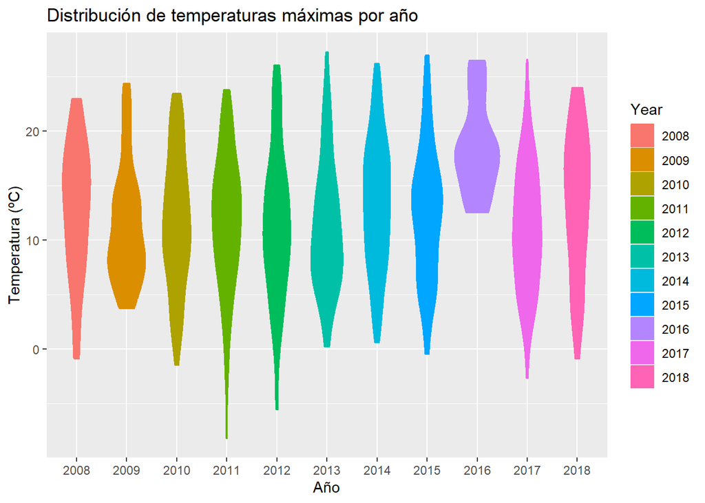

```r
# Esto es lo mismo al anterior. Cambia el llamado de Labs
ggplot(data = ds, mapping = aes(x = Year, y = MinTemp, color = Year)) +
  geom_violin(aes(fill = Year)) +
  labs(title = 'Distribución de temperaturas máximas por año',
       x = 'Año',
       y = 'Temperatura (ºC)')
```

- En el gráfico anterior elimina la leyenda y coloca los años en el eje $x$ a 45 grados de inclinación. Busca información en la red sobre cómo hacer esto.

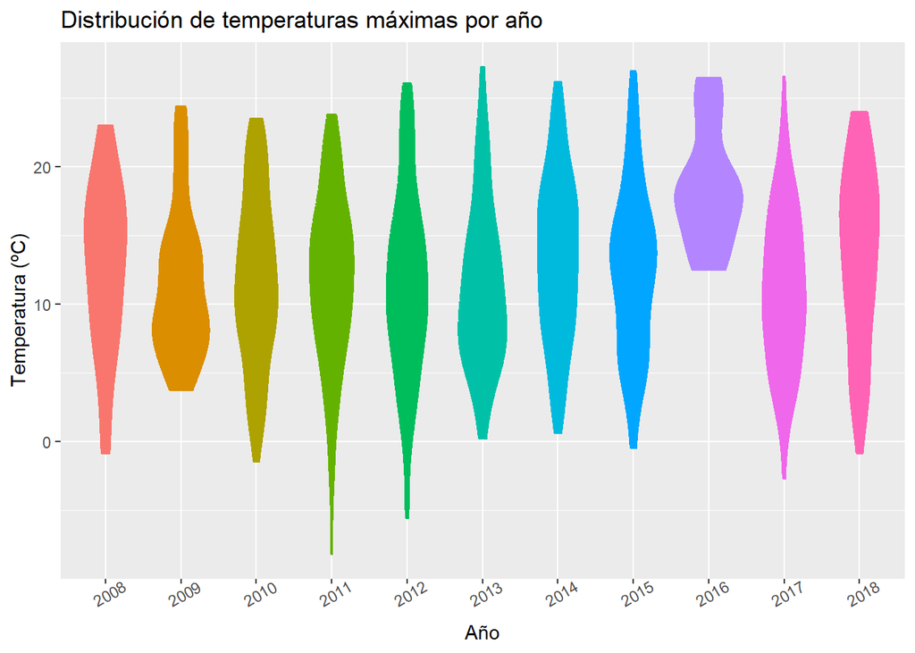

```r
g6 <- ggplot(data = ds, mapping = aes(x = Year, y = MinTemp, color = Year)) +
  geom_violin(aes(fill = Year)) +
  labs(title = 'Distribución de temperaturas máximas por año',
       x = 'Año',
       y = 'Temperatura (ºC)') +
  theme(legend.position = 'none',
        axis.text.x = element_text(angle = 30))
g6
```

- Almacena en formato **pdf** el gráfico resultante en un fichero denominado `Ejercicio6.pdf`.

```r
n_salida <- '6'
f_salida <- paste0(figuras, 'Ejercicio', n_salida, '.pdf')

# Grafico resultante
pdf(f_salida)
g6
dev.off()
```

# **Ejercicio 7**

- Descarga de la url “http://assets.datacamp.com/blog_assets/chol.txt” el dataset de datacamp que utilizarás para este ejercicio utilizando la función **read.table()**.

```r
# URL donde se descargara el fichero
url_ej <- 'http://assets.datacamp.com/blog_assets/chol.txt'

# Almacenamiento del fichero
fichero <- paste0(carpeta, 'chol.txt')

# Descarga
download.file(url = url_ej, destfile = fichero)

# Leemos el fichero
df <- read.table(file = fichero, header = TRUE)
head(df)
```

```
##   AGE HEIGHT WEIGHT CHOL  SMOKE BLOOD  MORT
## 1  20    176     77  195 nonsmo     b alive
## 2  53    167     56  250 sigare     o  dead
## 3  44    170     80  304 sigare     a  dead
## 4  37    173     89  178 nonsmo     o alive
## 5  26    170     71  206 sigare     o alive
## 6  41    165     62  284 sigare     o alive
```

- Representa el histograma de la variable `HEIGHT` del dataframe cargado del fichero anterior.

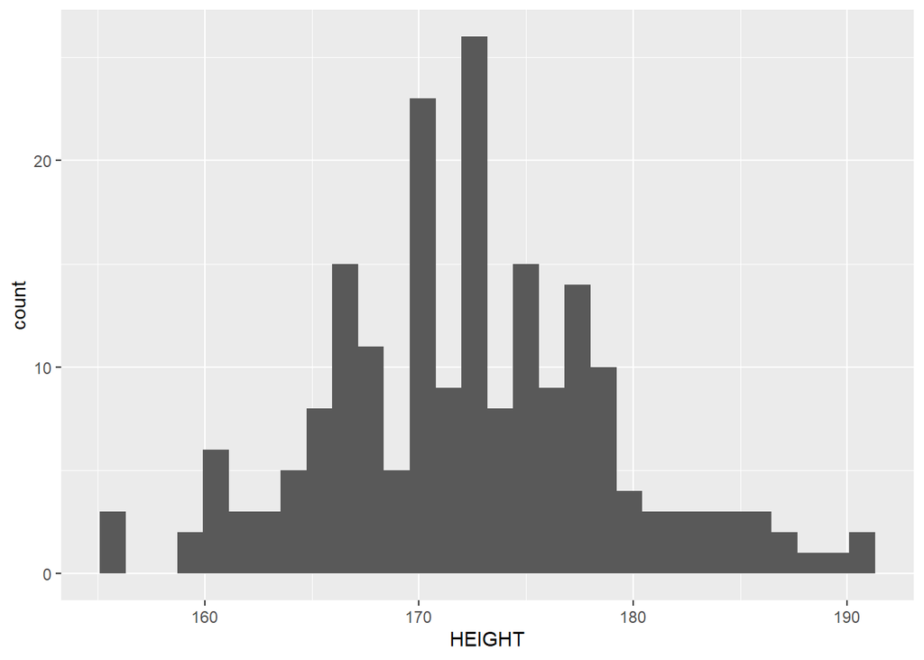

```r
# Sale un mensaje, indicando que por defecto, bins = 30
# Esto es porque no se especifica bins o binwidth

# count - por defecto
# Muestra cuántos datos caen dentro de cada intervalo (bin)
# Es una frecuencia absoluta
ggplot(data = df, aes(x = HEIGHT)) +
  geom_histogram()
```

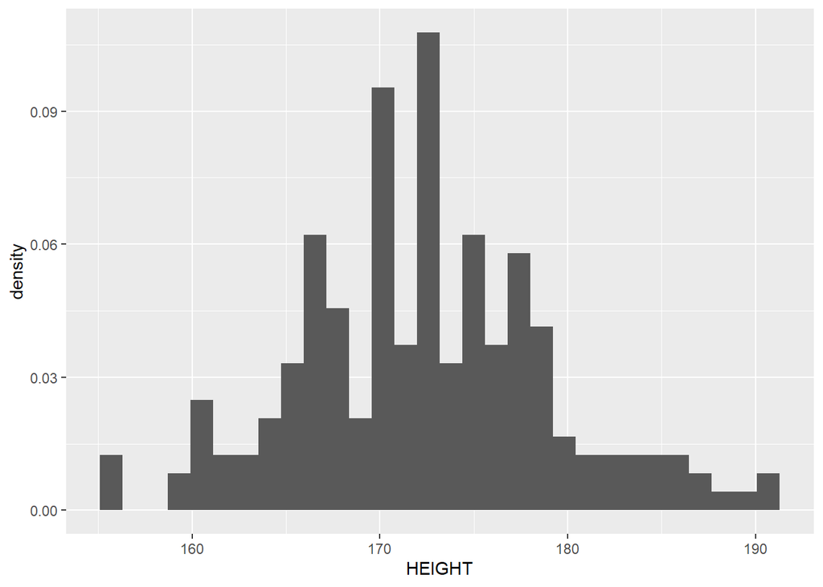

```r
# density
# Muestra la densidad de probabilidad
# Las áreas de las barras suman 1, no los valores en el eje y
# Se usa para comparar con una función de densidad (como una curva normal).
ggplot(data = df, aes(x = HEIGHT)) +
  geom_histogram(aes(y = after_stat(density))) # Eje y muestre la densidad, en lugar del conteo
```

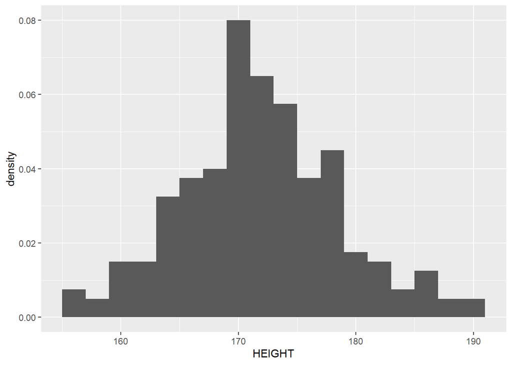

```r
ggplot(data = df, aes(x = HEIGHT)) +
  geom_histogram(aes(y = after_stat(density)), binwidth = 2) # binwidth = 2 define el ancho de la barra
```

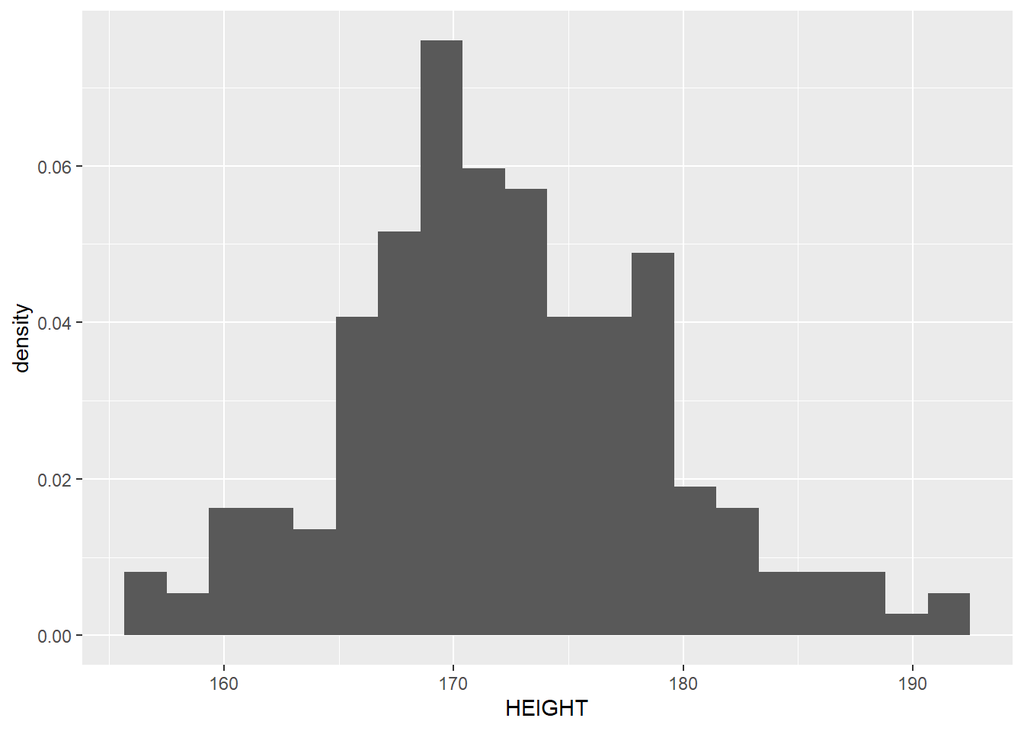

```r
ggplot(data = df, aes(x = HEIGHT)) +
  geom_histogram(aes(y = after_stat(density)), bins = 20) # bins = 20 define el total de barras
```

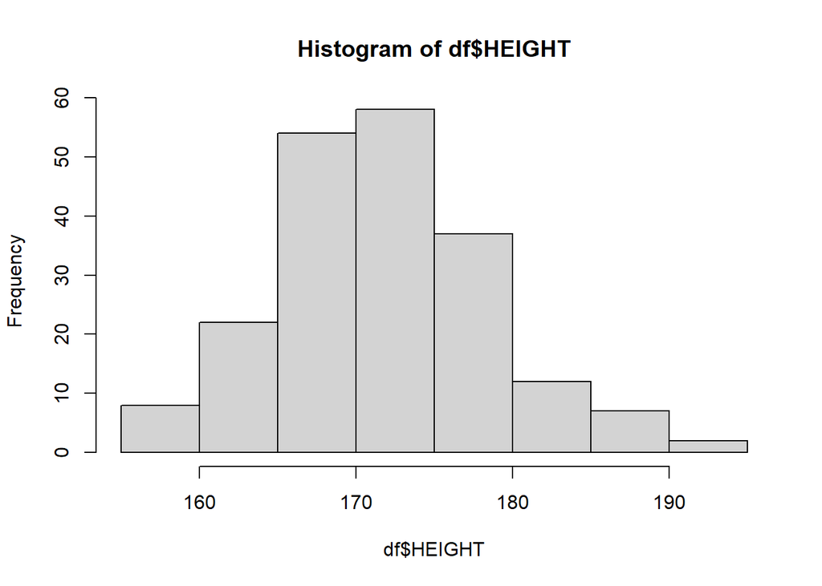

```r
# Otro ejemplo de histograma - sin ggplot
# breaks: número o posición de los cortes.
# freq: TRUE (frecuencia absoluta) o FALSE (densidad).
# col: color de las barras.
# border: color del borde.
hist(x = df$HEIGHT)
```

- Añade título (“Histograma de la variable Altura”), una etiqueta en el eje $x$ (“Altura (cm)”) y una etiqueta en el eje $y$ (“Frecuencia”).

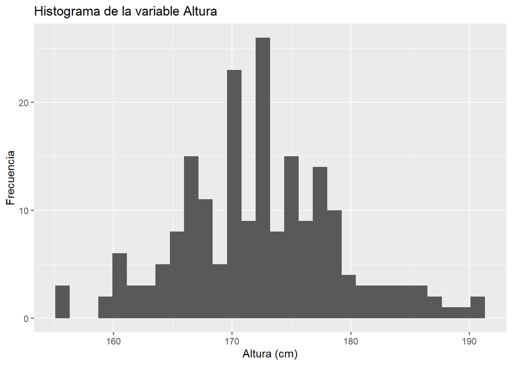

```r
ggplot(data = df, aes(x = HEIGHT)) +
  geom_histogram() +
  labs(title = 'Histograma de la variable Altura',
       x = 'Altura (cm)',
       y = 'Frecuencia')
```

- Ajusta el rango de representación entre 155 y 195, además consigue que el histograma tenga 20 *bins*.

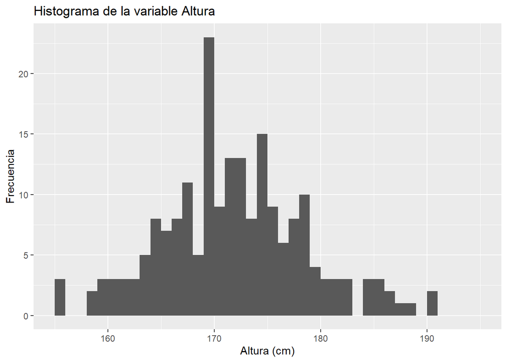

```r
ggplot(data = df, aes(x = HEIGHT)) +
  geom_histogram(breaks = seq(155, 195),
                 bins = 20) +
  labs(title = 'Histograma de la variable Altura',
       x = 'Altura (cm)',
       y = 'Frecuencia')
```

- Haz que las barras del histograma sean de color azul con una grado de transparencia del 50% y el contorno de color rojo.

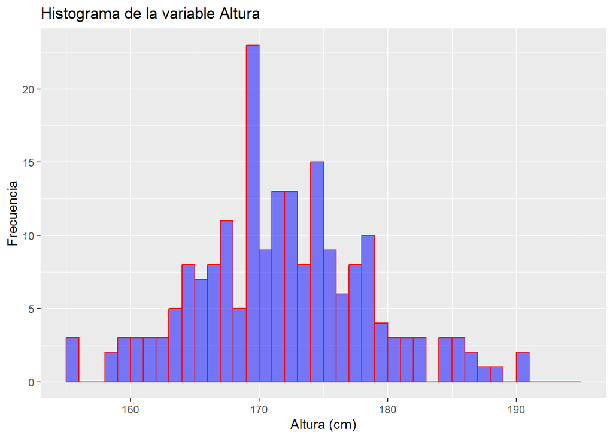

```r
# Los parametros están fuera de aes, porque es 'general'. No se asigna a una variable especifica
ggplot(data = df, aes(x = HEIGHT)) +
  geom_histogram(breaks = seq(155, 195),
                 bins = 20,
                 color = 'red',
                 fill = 'blue',
                 alpha = 0.5) +
  labs(title = 'Histograma de la variable Altura',
       x = 'Altura (cm)',
       y = 'Frecuencia')
```

- Añade la curva de distribución estimada de color verde.

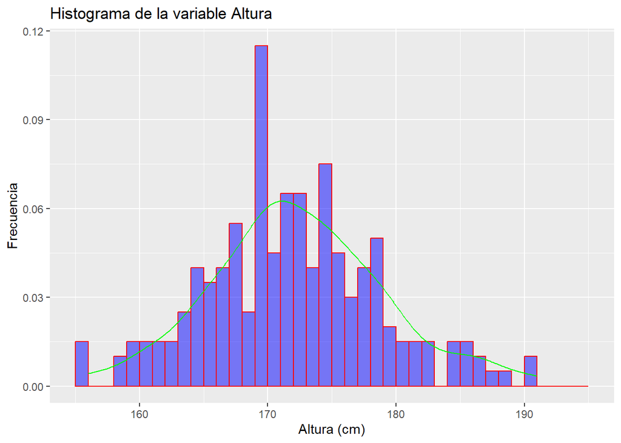

```r
ggplot(data = df, aes(x = HEIGHT)) +
  geom_histogram(aes(y = after_stat(density)),
                 breaks = seq(155, 195),
                 bins = 20,
                 color = 'red',
                 fill = 'blue',
                 alpha = 0.5) +
  labs(title = 'Histograma de la variable Altura',
       x = 'Altura (cm)',
       y = 'Frecuencia') +
  geom_density(color = 'green') # Para usar geom_density, debe usarse density en aes
```

- Representa el mismo histograma del apartado anterior para cada valor de la variable `MORT`, recuerda utilizar la función **facet_grid()**.

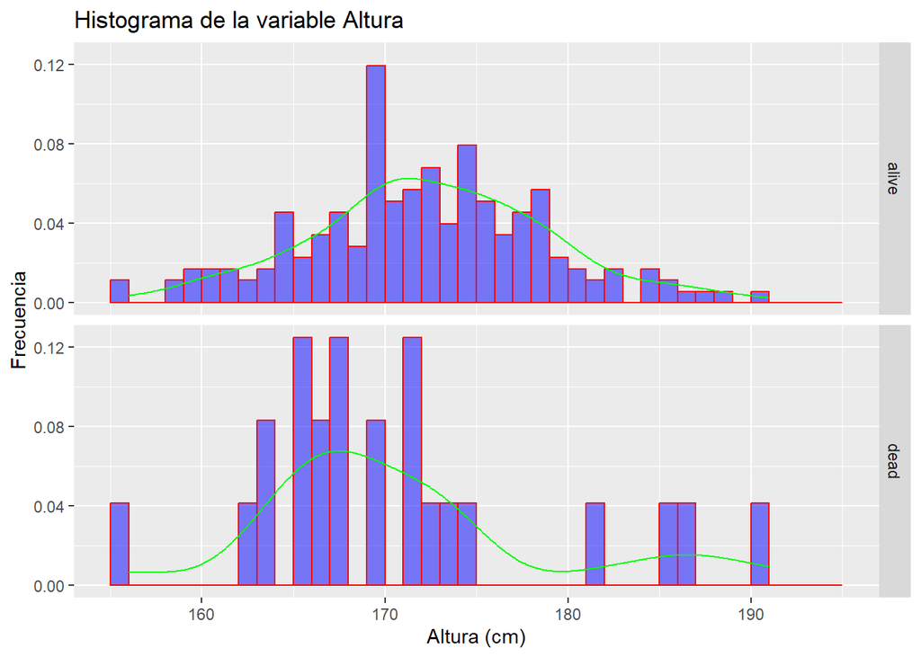

```r
ggplot(data = df, aes(x = HEIGHT)) +
  geom_histogram(aes(y = after_stat(density)),
                 breaks = seq(155, 195),
                 bins = 20,
                 color = 'red',
                 fill = 'blue',
                 alpha = 0.5) +
  labs(title = 'Histograma de la variable Altura',
       x = 'Altura (cm)',
       y = 'Frecuencia') +
  geom_density(color = 'green') +
  facet_grid(MORT~.) # Horizontal
```

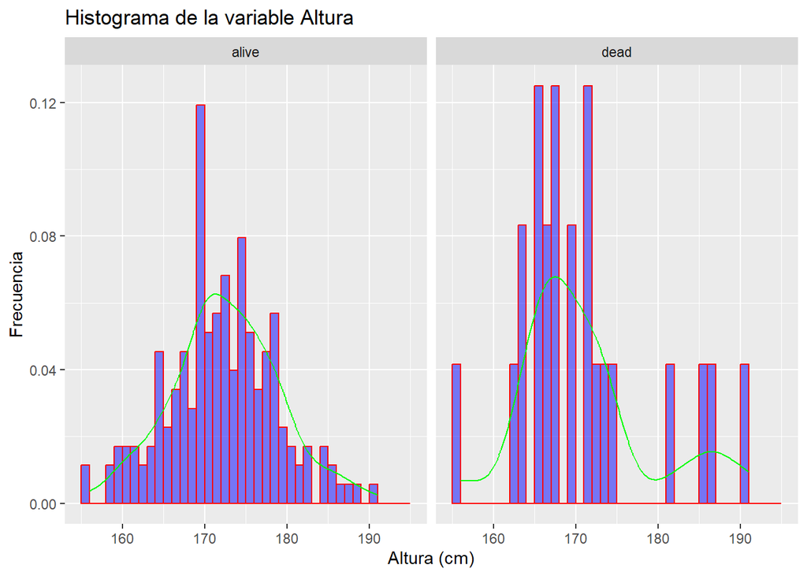

```r
g7 <- ggplot(data = df, aes(x = HEIGHT)) +
  geom_histogram(aes(y = after_stat(density)),
                 breaks = seq(155, 195),
                 bins = 20,
                 color = 'red',
                 fill = 'blue',
                 alpha = 0.5) +
  labs(title = 'Histograma de la variable Altura',
       x = 'Altura (cm)',
       y = 'Frecuencia') +
  geom_density(color = 'green') +
  facet_grid(.~MORT) # vertical
g7
```

- Almacena en formato **pdf** el gráfico resultante en un fichero denominado `Ejercicio7.pdf`.

```r
n_salida <- '7'
f_salida <- paste0(figuras, 'Ejercicio', n_salida, '.pdf')

# Grafico resultante
pdf(f_salida)
g7
dev.off()
```